# DALEX - A great companion of h2o::automl()

Hoang Thien Ly

Created on July 7, 2021

# 1 Introduction:

After the stage of analyzing data and feature engineering, the challenge of applying machine learning turns out to be seeking for the finest model among various models to your predictive problem.

Motivated to tackle this craft, the `H2OAutoML` tool was created in order to automatically propose good models for your problem. However, will we be able to display what happened in this black box or be able to have any evidence-based reasons to avoid the reluctance in applying the proposed model? To answer this, in this vignette, we will illuminate the choosing model process with explanation by means of `DALEX` and `modelStudio`.

# 2 Data set

```r
library(DALEX)
library(h2o)
set.seed(17)
```

We will use a dataset named `dragons` which is artificially generated and available in the `DALEX` package.

Our aim is to solve this regression problem, particularly, predict the year of birth of a dragon based on features such as height, weight, number of scars, colour, year of discovery, number of lost teeth, and life expectancy. Note that, negative values in the year of birth indicate dates B.C and non-negative values indicate dates A.D.

```r
options(width = 150)
data(dragons)
head(dragons)
```

```
##   year_of_birth   height   weight scars colour year_of_discovery number_of_lost_teeth life_length
## 1         -1291 59.40365 15.32391     7    red              1700                   25   1368.4331
## 2          1589 46.21374 11.80819     5    red              1700                   28   1377.0474
## 3          1528 49.17233 13.34482     6    red              1700                   38   1603.9632
## 4          1645 48.29177 13.27427     5  green              1700                   33   1434.4222
## 5            -8 49.99679 13.08757     1    red              1700                   18    985.4905
## 6           915 45.40876 11.48717     2    red              1700                   20    969.5682
```

# 3 H2O AutoML & problem of choosing model

## 3.1 Problem defining in h2o::automl()

We run this chunk of code to initialize the H2O environment.

```r
h2o.init()
```

In the step of defining problem, our target “target” is year_of_birth of a dragon, our data frame “df” `dragons` is converted to `H2O DataFrame`.

```r
h2o.no_progress()
target <- "year_of_birth"
df <- as.h2o(dragons)
```

## 3.2 Creating model by H2O AutoML

```r
model_h2o_automl <- h2o.automl(y = target, training_frame = df, max_runtime_secs = 90, max_models = 20)
```

From the cooked `model_h2o_automl`, we can, for instance, get the leader board of finest models for our model in those restrictions of stopping criteria. In this case, the answer is Stacked Ensemble All Models in AutoML, as attached in the table below.

```r
leader_board <- h2o.get_leaderboard(model_h2o_automl)
head(leader_board)
```

```
##                                              model_id mean_residual_deviance      rmse       mse      mae rmsle
## 1    StackedEnsemble_AllModels_AutoML_20210725_212628               874499.3  935.1467  874499.3 720.9784   NaN
## 2 StackedEnsemble_BestOfFamily_AutoML_20210725_212628               874881.5  935.3510  874881.5 721.5379   NaN
## 3 DeepLearning_grid__2_AutoML_20210725_212628_model_1               883526.4  939.9609  883526.4 714.4234   NaN
## 4 DeepLearning_grid__2_AutoML_20210725_212628_model_2              1141039.0 1068.1943 1141039.0 919.3835   NaN
## 5 DeepLearning_grid__1_AutoML_20210725_212628_model_1              1169438.7 1081.4059 1169438.7 914.0641   NaN
## 6               DeepLearning_1_AutoML_20210725_212628              1183385.1 1087.8350 1183385.1 934.0850   NaN
```

# 4 Wrapping things up and explaining with `explain()` function

## 4.1 Creating explainer

Until this step, we all know which model we should choose to get high performance as a result of running `H2O AutoML`. Eventually, to know what function inside the `H2O AutoML`, what important features are,… If all the answers to those questions are obtained, the credibility and transparency of our choice for Machine learning problem would be significantly increased.

Followingly, we will show how to use the `explain()` function from `DALEX` package to answer those riddles coming from the recommended model of `H2O AutoML`.

In the first step of using `DALEX`, we need to conclude the model from `H2O AutoML` with some other important parameters:

- model: the model we obtained from H2O AutoML, in our case is: `model_h2o_automl`.
- data: the validation set, in this case, we will use `dragons_test` dataset without the first column year_of_birth
- y: our target, here is column year_of_birth

```r
library(DALEXtra)
explainer_h2o_automl <- DALEXtra::explain_h2o(model = model_h2o_automl,
                                              data = dragons_test[,2:8],
                                              y=dragons_test$year_of_birth,
                                              label = "h2o automl",
                                              colorize = FALSE)
```

## 4.2 Model performance:

Function `model_performance()` calculates the assessment for prediction and residuals for validation dataset.

```r
mp_h2o_automl <- model_performance(explainer_h2o_automl)
mp_h2o_automl
```

```
## Measures for:  regression
## mse        : 17793634
## rmse       : 4218.25
## r2         : -12.38569
## mad        : 1834.862
##
## Residuals:
##          0%         10%         20%         30%         40%         50%         60%         70%         80%         90%        100%
## -14127.4109  -8015.4613  -4779.5212  -3349.6888  -2394.4822  -1725.2108  -1179.5217   -652.7621   -147.2732    372.6013   2444.6571
```

Function `plot()` below shows reversed empirical cummulative distribution function for absolute values from residuals.

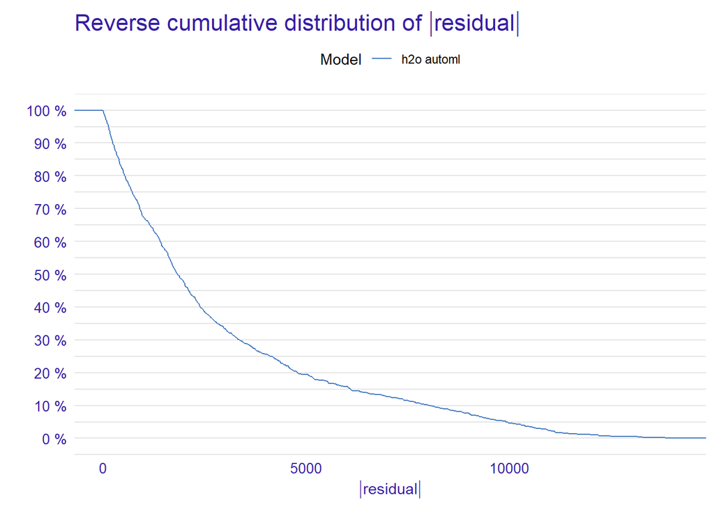

```r
plot(mp_h2o_automl)
```

We can also use boxplot type to see the distribution of residuals of selected model.

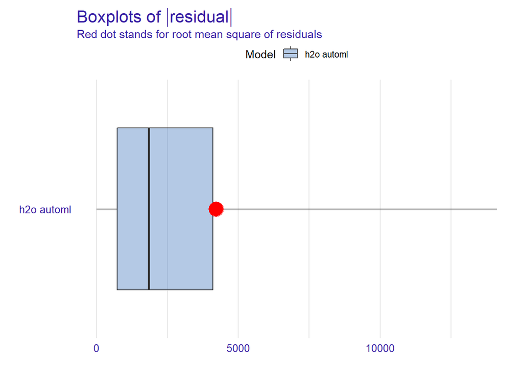

```r
plot(mp_h2o_automl,geom="boxplot")
```

## 4.3 Variable importance

By using the `DALEX` package, we are able to deepen our understanding on important variables.

Model agnostic variable importance is calculated by means of permutations. We simply subtract the loss function calculated for the validation dataset with permuted values for a single variable from the loss function calculated for the validation dataset.

This method is implemented in the `model_parts()` function.

```r
fe_h2o_automl <- model_parts(explainer_h2o_automl)
```

The length of the bar represents the importance of that variable. Longer the bar is, more loss is while permuting this variable and keeping the rest, consequently, more important this variable is.

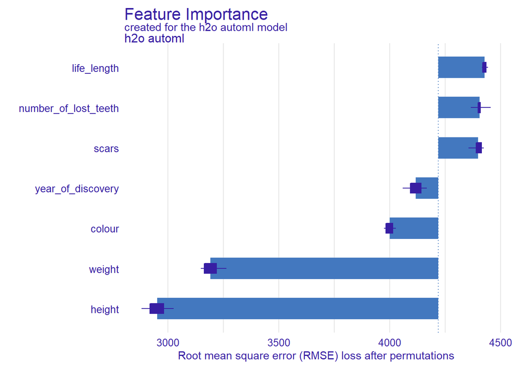

```r
plot(fe_h2o_automl)
```

## 4.4 Variable response

There are two main types of plots: **Partial Dependence plot** and **Accumulated Local Effects plot** designed for the sake of exploring the relation between a variable with the model outcome (in our case: year_of_birth)

### 4.4.1 Partial Dependence Plot (PDP)

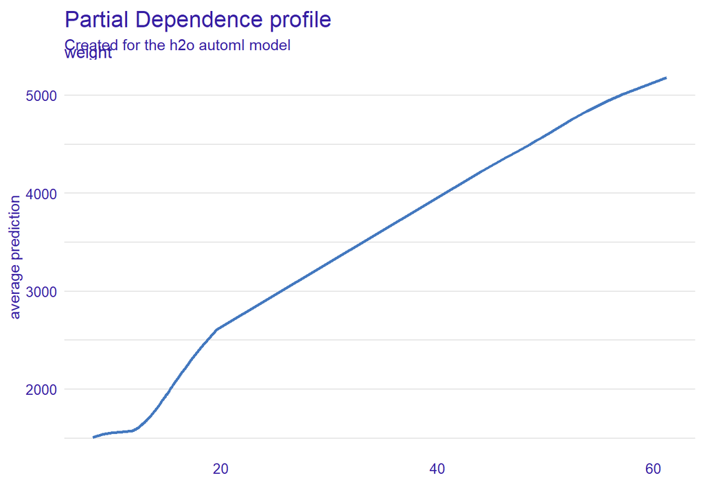

```r
pdp_h2o_automl <- model_profile(explainer_h2o_automl,variable = "weight", type="partial")

plot(pdp_h2o_automl)
```

### 4.4.2 Accumulated Local Effects plot

**ALE** is an extention of PDP which suits for highly correlated variables.

Function `model_profile()` with parameter type=“accumulated” calculate the **ALE** curve for variable weight

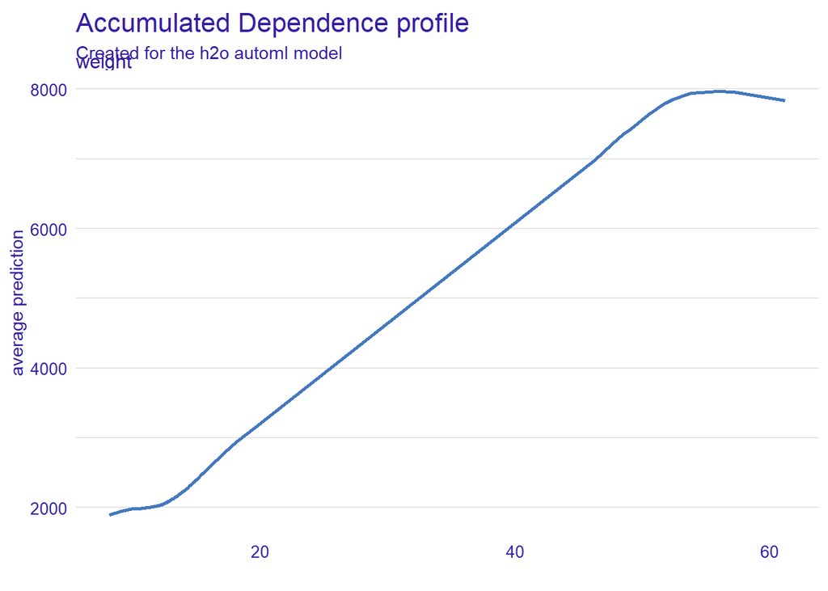

```r
ale_h2o_automl <- model_profile(explainer_h2o_automl,variable = "weight", type="accumulated")
plot(ale_h2o_automl)
```

## 4.5 Prediction understanding:

Model prediction is visualized with **Break Down Plots**, which shows the contribution of each variable presenting in the model. Function `predict_parts()` generates variable attributions for chosen prediction. The `plot()` function shows these attributions.

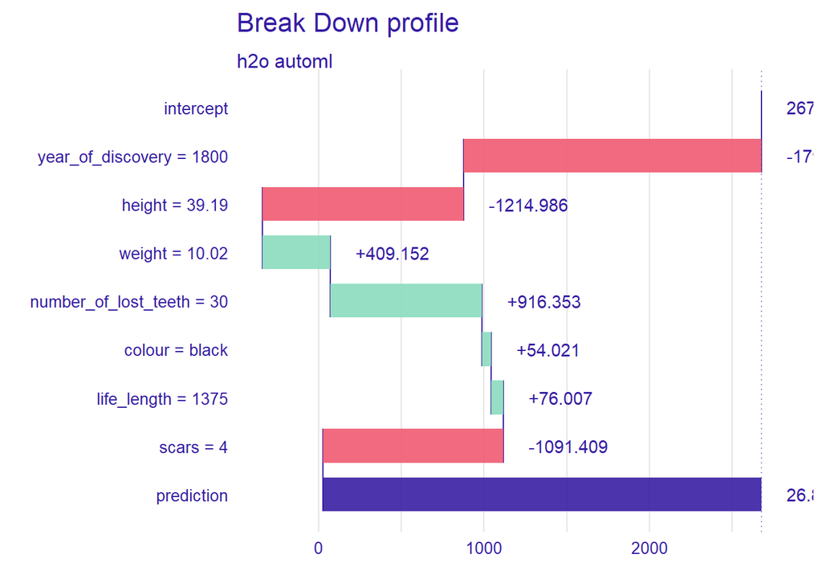

```r
new_date_birth <- dragons_test[1,]
pb_h2o_automl <- predict_parts(explainer_h2o_automl,new_observation = new_date_birth,type="break_down")

plot(pb_h2o_automl)
```

# 5 Model Studio

We can automate the previous process by using `modelStudio` package. The main `modelStudio()` function computes various (instance and model-level) explanations and produces a customisable dashboard.

```r
library(modelStudio)
modelStudio::modelStudio(explainer_h2o_automl)
```

# 6 Section info